# Part 1

Lauren Kennedy

2023-01-15

# Running a simple brms model

First we will simulate a simple dataset to understand prior predictive checks.

We create this dataset as a simple intercept only model. This is a small modification on a linear regression to use a logistic link. This allows us to model probability on a (0,1) scale.

$$p(y=1) =
logit^{-1}(\beta_0)$$

Create the data:

```r
library(tidyverse)
set.seed(18383)

ex_data1 <- data.frame(p_y = rep(.2, 100))%>%
  mutate(y_obs = rbinom(100,1,p_y))
```

This following chunk runs this code with rstan (the default backend for brms). Do not install rstan for the purposes of running this chunk! It is included to demonstrate the speed differences (about half of the time) of cmdstanr. You can skip it by writing “eval = FALSE” in the curly braces at the top of the chunk.

```r
# Do not run without rstan installed (don't run for this one chunk)
library(brms)
library(tictoc)
tic()
ex_mod1 <- brm(y_obs ~ 1, data = ex_data1, family = binomial(link = "logit"))
```

```
## Using the maximum response value as the number of trials.
```

```
## Only 2 levels detected so that family 'bernoulli' might be a more efficient choice.
```

```r
toc()
```

```
## 40.62 sec elapsed
```

You can skip the speed timing and follow by just running the code. It takes about half as long though! :)

```r
library(tictoc)
library(brms)
tic()
ex_mod1 <- brm(y_obs ~ 1, data = ex_data1, family = binomial(link = "logit"), backend = "cmdstanr")
```

```
## Using the maximum response value as the number of trials.
```

```
## Only 2 levels detected so that family 'bernoulli' might be a more efficient choice.
```

[output not shown]

[output cut: 43 more lines]

[output not shown]

```r
toc()
```

```
## 20.39 sec elapsed
```

Let’s see what the object returns

```r
ex_mod1
```

```
##  Family: binomial
##   Links: mu = logit
## Formula: y_obs ~ 1
##    Data: ex_data1 (Number of observations: 100)
##   Draws: 4 chains, each with iter = 2000; warmup = 1000; thin = 1;
##          total post-warmup draws = 4000
##
## Population-Level Effects:
##           Estimate Est.Error l-95% CI u-95% CI Rhat Bulk_ESS Tail_ESS
## Intercept    -1.74      0.28    -2.32    -1.22 1.00     1535     1721
##
## Draws were sampled using sample(hmc). For each parameter, Bulk_ESS
## and Tail_ESS are effective sample size measures, and Rhat is the potential
## scale reduction factor on split chains (at convergence, Rhat = 1).
```

Let’s run the same code a little more efficiently by sampling each chain in parallel rather than serially. It doesn’t make a dramatic differences in this instance because sampling is a much smaller proportion of time than compiling. However, in more complex models with more data, the opposite is true and this can make a big difference.

```r
tic()
ex_mod1 <- brm(y_obs ~ 1, data = ex_data1, family = binomial(link = "logit"), backend = "cmdstanr", cores = 4)
```

```
## Using the maximum response value as the number of trials.
```

```
## Only 2 levels detected so that family 'bernoulli' might be a more efficient choice.
```

[output not shown]

[output cut: 43 more lines]

[output not shown]

```r
toc()
```

```
## 18.98 sec elapsed
```

Using the posterior packages to extract the output. This can be used to create other posterior summaries.

```r
library(posterior)
```

```r
ex1_draws <- as_draws_df(ex_mod1)
```

Want to modify your model but can’t in brms syntax?

```r
stancode(ex_mod1)
```

```
## // generated with brms 2.18.0
## functions {
##
## }
## data {
##   int<lower=1> N; // total number of observations
##   array[N] int Y; // response variable
##   array[N] int trials; // number of trials
##   int prior_only; // should the likelihood be ignored?
## }
## transformed data {
##
## }
## parameters {
##   real Intercept; // temporary intercept for centered predictors
## }
## transformed parameters {
##   real lprior = 0; // prior contributions to the log posterior
##   lprior += student_t_lpdf(Intercept | 3, 0, 2.5);
## }
## model {
##   // likelihood including constants
##   if (!prior_only) {
##     // initialize linear predictor term
##     vector[N] mu = rep_vector(0.0, N);
##     mu += Intercept;
##     target += binomial_logit_lpmf(Y | trials, mu);
##   }
##   // priors including constants
##   target += lprior;
## }
## generated quantities {
##   // actual population-level intercept
##   real b_Intercept = Intercept;
## }
##
```

# How to do a prior predictive check and work with priors in brms

See a summary of the priors from an existing model

```r
prior_summary(ex_mod1)
```

```
## Intercept ~ student_t(3, 0, 2.5)
```

Sample from the prior only

```r
ex_prior1 <- brm(y_obs ~ 1, data = ex_data1, family = binomial(link = "logit"), backend = "cmdstanr", cores = 4, sample_prior = "only")
```

```
## Using the maximum response value as the number of trials.
```

```
## Only 2 levels detected so that family 'bernoulli' might be a more efficient choice.
```

[output not shown]

[output cut: 43 more lines]

[output not shown]

Use this to predict the probability:

```r
ex1_prior_linpred <- posterior_linpred(ex_prior1)
```

```
## Using the maximum response value as the number of trials.
```

```r
dim(ex1_prior_linpred)
```

```
## [1] 4000  100
```

```r
ex1_prior_linpred[1:10,1:10]
```

```
##            [,1]      [,2]      [,3]      [,4]      [,5]      [,6]      [,7]
##  [1,]  2.545830  2.545830  2.545830  2.545830  2.545830  2.545830  2.545830
##  [2,]  1.990830  1.990830  1.990830  1.990830  1.990830  1.990830  1.990830
##  [3,]  2.292870  2.292870  2.292870  2.292870  2.292870  2.292870  2.292870
##  [4,] -0.634198 -0.634198 -0.634198 -0.634198 -0.634198 -0.634198 -0.634198
##  [5,]  2.932060  2.932060  2.932060  2.932060  2.932060  2.932060  2.932060
##  [6,]  0.587996  0.587996  0.587996  0.587996  0.587996  0.587996  0.587996
##  [7,]  0.144495  0.144495  0.144495  0.144495  0.144495  0.144495  0.144495
##  [8,]  4.594430  4.594430  4.594430  4.594430  4.594430  4.594430  4.594430
##  [9,]  4.687280  4.687280  4.687280  4.687280  4.687280  4.687280  4.687280
## [10,]  2.505900  2.505900  2.505900  2.505900  2.505900  2.505900  2.505900
##            [,8]      [,9]     [,10]
##  [1,]  2.545830  2.545830  2.545830
##  [2,]  1.990830  1.990830  1.990830
##  [3,]  2.292870  2.292870  2.292870
##  [4,] -0.634198 -0.634198 -0.634198
##  [5,]  2.932060  2.932060  2.932060
##  [6,]  0.587996  0.587996  0.587996
##  [7,]  0.144495  0.144495  0.144495
##  [8,]  4.594430  4.594430  4.594430
##  [9,]  4.687280  4.687280  4.687280
## [10,]  2.505900  2.505900  2.505900
```

Transform to probabilities

```r
ex1_prior_linpred <- posterior_linpred(ex_prior1, transform = TRUE)
```

```
## Using the maximum response value as the number of trials.
```

```r
ex1_prior_linpred[1:10,1:10]
```

```
##            [,1]      [,2]      [,3]      [,4]      [,5]      [,6]      [,7]
##  [1,] 0.9272929 0.9272929 0.9272929 0.9272929 0.9272929 0.9272929 0.9272929
##  [2,] 0.8798309 0.8798309 0.8798309 0.8798309 0.8798309 0.8798309 0.8798309
##  [3,] 0.9082848 0.9082848 0.9082848 0.9082848 0.9082848 0.9082848 0.9082848
##  [4,] 0.3465593 0.3465593 0.3465593 0.3465593 0.3465593 0.3465593 0.3465593
##  [5,] 0.9494087 0.9494087 0.9494087 0.9494087 0.9494087 0.9494087 0.9494087
##  [6,] 0.6429052 0.6429052 0.6429052 0.6429052 0.6429052 0.6429052 0.6429052
##  [7,] 0.5360610 0.5360610 0.5360610 0.5360610 0.5360610 0.5360610 0.5360610
##  [8,] 0.9899932 0.9899932 0.9899932 0.9899932 0.9899932 0.9899932 0.9899932
##  [9,] 0.9908724 0.9908724 0.9908724 0.9908724 0.9908724 0.9908724 0.9908724
## [10,] 0.9245544 0.9245544 0.9245544 0.9245544 0.9245544 0.9245544 0.9245544
##            [,8]      [,9]     [,10]
##  [1,] 0.9272929 0.9272929 0.9272929
##  [2,] 0.8798309 0.8798309 0.8798309
##  [3,] 0.9082848 0.9082848 0.9082848
##  [4,] 0.3465593 0.3465593 0.3465593
##  [5,] 0.9494087 0.9494087 0.9494087
##  [6,] 0.6429052 0.6429052 0.6429052
##  [7,] 0.5360610 0.5360610 0.5360610
##  [8,] 0.9899932 0.9899932 0.9899932
##  [9,] 0.9908724 0.9908724 0.9908724
## [10,] 0.9245544 0.9245544 0.9245544
```

For comparison:

```r
ex1_prior_epred <- posterior_epred(ex_prior1)
```

```
## Using the maximum response value as the number of trials.
```

```r
ex1_prior_epred[1:10,1:10]
```

```
##            [,1]      [,2]      [,3]      [,4]      [,5]      [,6]      [,7]
##  [1,] 0.9272929 0.9272929 0.9272929 0.9272929 0.9272929 0.9272929 0.9272929
##  [2,] 0.8798309 0.8798309 0.8798309 0.8798309 0.8798309 0.8798309 0.8798309
##  [3,] 0.9082848 0.9082848 0.9082848 0.9082848 0.9082848 0.9082848 0.9082848
##  [4,] 0.3465593 0.3465593 0.3465593 0.3465593 0.3465593 0.3465593 0.3465593
##  [5,] 0.9494087 0.9494087 0.9494087 0.9494087 0.9494087 0.9494087 0.9494087
##  [6,] 0.6429052 0.6429052 0.6429052 0.6429052 0.6429052 0.6429052 0.6429052
##  [7,] 0.5360610 0.5360610 0.5360610 0.5360610 0.5360610 0.5360610 0.5360610
##  [8,] 0.9899932 0.9899932 0.9899932 0.9899932 0.9899932 0.9899932 0.9899932
##  [9,] 0.9908724 0.9908724 0.9908724 0.9908724 0.9908724 0.9908724 0.9908724
## [10,] 0.9245544 0.9245544 0.9245544 0.9245544 0.9245544 0.9245544 0.9245544
##            [,8]      [,9]     [,10]
##  [1,] 0.9272929 0.9272929 0.9272929
##  [2,] 0.8798309 0.8798309 0.8798309
##  [3,] 0.9082848 0.9082848 0.9082848
##  [4,] 0.3465593 0.3465593 0.3465593
##  [5,] 0.9494087 0.9494087 0.9494087
##  [6,] 0.6429052 0.6429052 0.6429052
##  [7,] 0.5360610 0.5360610 0.5360610
##  [8,] 0.9899932 0.9899932 0.9899932
##  [9,] 0.9908724 0.9908724 0.9908724
## [10,] 0.9245544 0.9245544 0.9245544
```

For comparison:

```r
ex1_prior_predict <- posterior_predict(ex_prior1)
```

```
## Using the maximum response value as the number of trials.
```

```r
ex1_prior_predict[1:10,1:10]
```

```
##       [,1] [,2] [,3] [,4] [,5] [,6] [,7] [,8] [,9] [,10]
##  [1,]    1    1    1    1    1    1    1    1    1     1
##  [2,]    0    1    1    1    1    1    1    1    1     0
##  [3,]    1    1    1    1    1    1    1    1    1     0
##  [4,]    0    0    0    0    0    0    1    1    1     0
##  [5,]    1    1    1    1    1    1    1    1    1     1
##  [6,]    0    1    1    1    0    0    1    1    1     0
##  [7,]    0    1    1    1    0    0    0    0    0     0
##  [8,]    1    1    1    1    1    0    1    1    1     1
##  [9,]    1    1    1    1    1    1    1    1    1     1
## [10,]    0    1    1    1    1    1    1    1    1     1
```

Visualising the prior for one observation in terms of the expected probability:

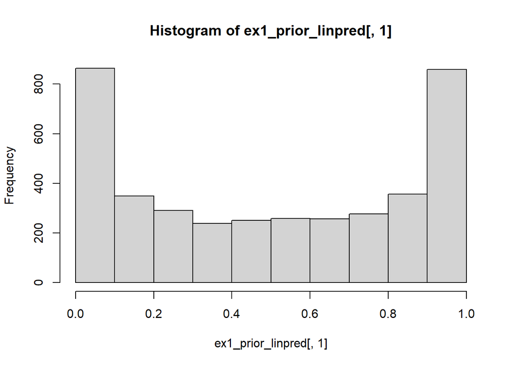

```r
hist(ex1_prior_linpred[,1])
```

# Changing the prior

```r
get_prior(y_obs ~ 1, data = ex_data1, family = binomial(link = "logit"))
```

```
## Intercept ~ student_t(3, 0, 2.5)
```

```r
prior_ex1 <- prior(normal(0,1), class= Intercept)
prior_ex1
```

```
## Intercept ~ normal(0, 1)
```

```r
make_stancode(y_obs ~ 1, data = ex_data1, family = binomial(link = "logit"), prior = prior_ex1)
```

```
## // generated with brms 2.18.0
## functions {
## }
## data {
##   int<lower=1> N;  // total number of observations
##   int Y[N];  // response variable
##   int trials[N];  // number of trials
##   int prior_only;  // should the likelihood be ignored?
## }
## transformed data {
## }
## parameters {
##   real Intercept;  // temporary intercept for centered predictors
## }
## transformed parameters {
##   real lprior = 0;  // prior contributions to the log posterior
##   lprior += normal_lpdf(Intercept | 0, 1);
## }
## model {
##   // likelihood including constants
##   if (!prior_only) {
##     // initialize linear predictor term
##     vector[N] mu = rep_vector(0.0, N);
##     mu += Intercept;
##     target += binomial_logit_lpmf(Y | trials, mu);
##   }
##   // priors including constants
##   target += lprior;
## }
## generated quantities {
##   // actual population-level intercept
##   real b_Intercept = Intercept;
## }
```

```r
ex_prior1_v2 <- brm(y_obs ~ 1, data = ex_data1, family = binomial(link = "logit"), backend = "cmdstanr", cores = 4, sample_prior = "only", prior = prior_ex1)
```

```
## Using the maximum response value as the number of trials.
```

```
## Only 2 levels detected so that family 'bernoulli' might be a more efficient choice.
```

[output not shown]

[output cut: 43 more lines]

[output not shown]

```r
ex1_prior2_linpred <- posterior_linpred(ex_prior1_v2, transform = TRUE)
```

```
## Using the maximum response value as the number of trials.
```

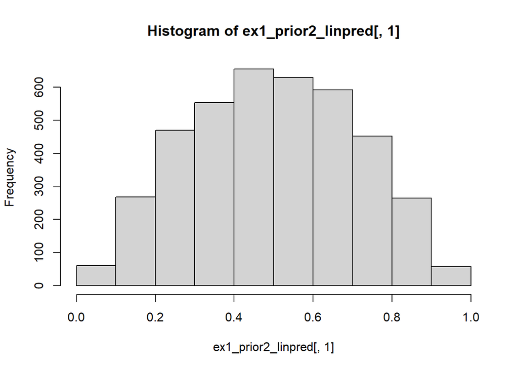

```r
hist(ex1_prior2_linpred[,1])
```